# Analytics Programming Week-2

```r
#12 b Solution
total.daily.tasks_sum = sum(total.daily.tasks, na.rm = TRUE)
print(paste("Sum", total.daily.tasks_sum))
```

```
## [1] "Sum 99"
```

#13 Write a function that will display the question below and return the correct answer. #a. Was Joanne able to complete more tasks when she drank coffee or days when she did not drink coffee?

```r
compare_task_function <- function(task) {
  # Compare the totals and return the appropriate message
  if (without_coffee_task_sum > with_coffee_task_sum) {
    return("Joanne was able to complete more tasks without coffee than with coffee.")
  } else if (without_coffee_task_sum < with_coffee_task_sum) {
    return("Joanne was able to complete more tasks with coffee than without coffee.")
  } else {
    return("Joanne completed the same number of tasks with or without coffee.")
  }
}

print(compare_task_function(joanneTasks))
```

```
## [1] "Joanne was able to complete more tasks without coffee than with coffee."
```

##14. Select two quantitative variables (from Taxes, Price, Size, and Lot) ##a. Draw histogram for the two selected quantitative variables. ##b. Draw the density plot for the two selected quantitative variables.

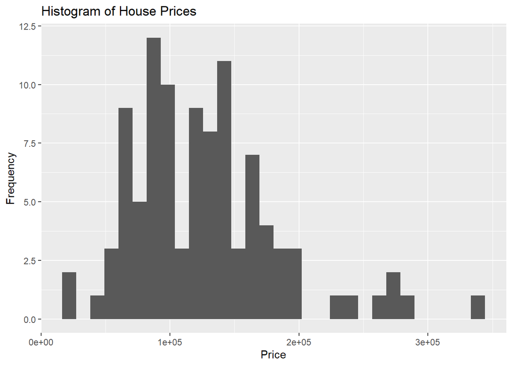

```r
library(ggplot2)
library(readxl)

housing_data <- read_excel("D:/Webster University/Assignments/Analytics Programming/Week-2/house_selling_prices_FL.xlsx")

#Solution for 14 a

ggplot(housing_data, aes(x=price)) +geom_histogram()+
  ggtitle("Histogram of House Prices") +
  xlab("Price") +
  ylab("Frequency");
```

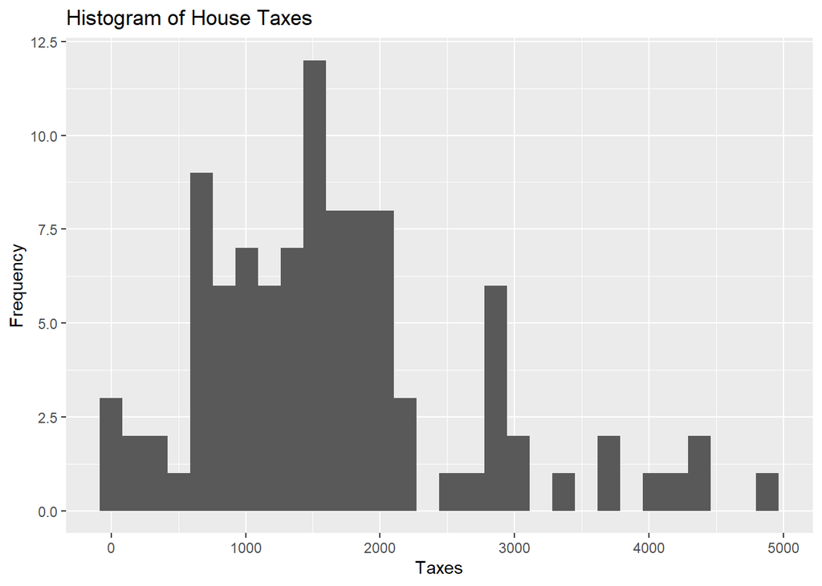

```r
ggplot(housing_data, aes(x=Taxes)) +geom_histogram()+
  ggtitle("Histogram of House Taxes") +
  xlab("Taxes")+
  ylab("Frequency");
```

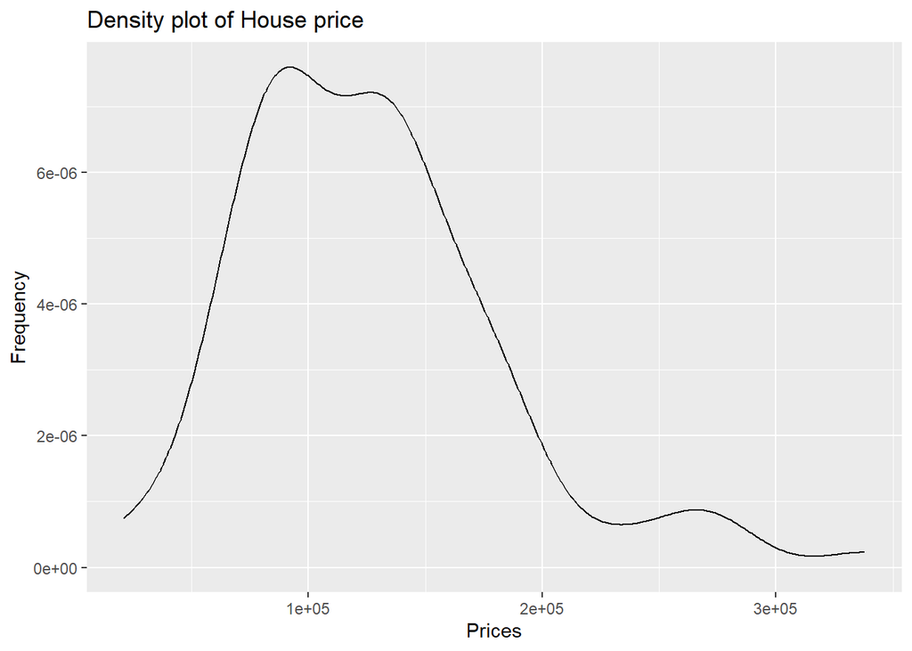

```r
#Solution for 14 b

ggplot(housing_data, aes(x=price)) +geom_density()+
  ggtitle("Density plot of House price") +
  xlab("Prices") +
  ylab("Frequency");
```

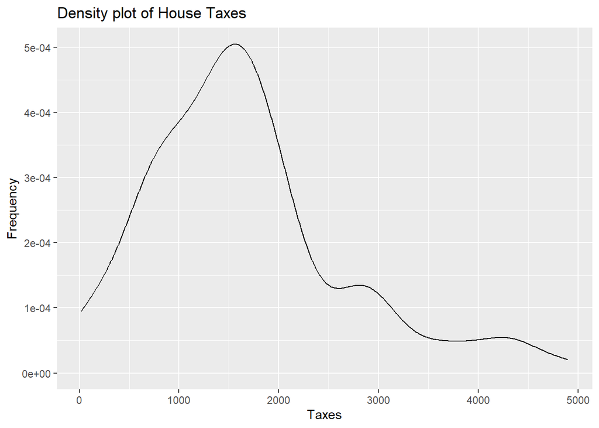

```r
ggplot(housing_data, aes(x=Taxes)) +geom_density()+
  ggtitle("Density plot of House Taxes") +
  xlab("Taxes") +
  ylab("Frequency");
```

##15. Select the categorical variable Quadrant. ##a. Draw Pareto chart.

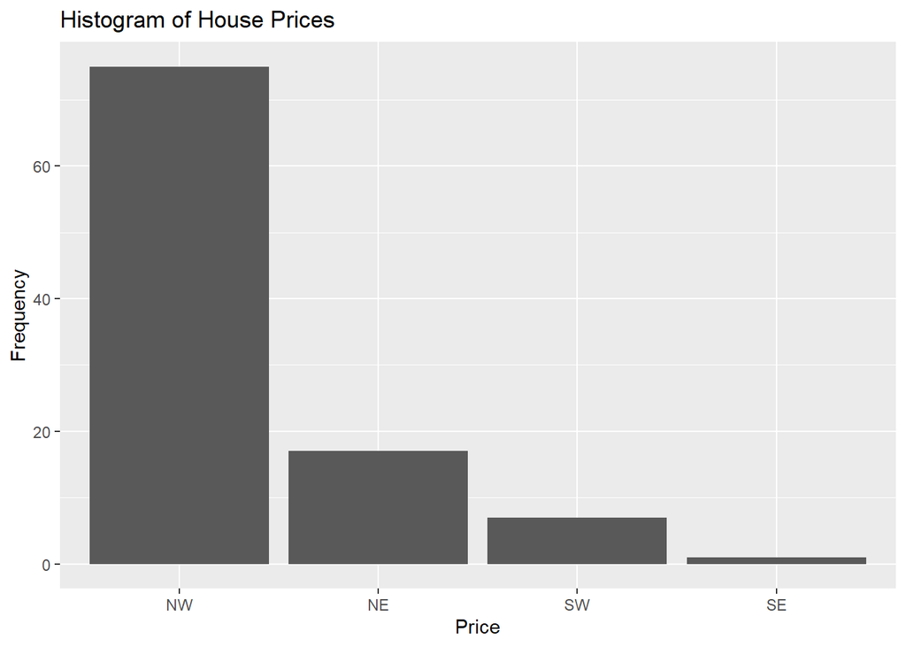

```r
library(forcats)
ggplot(housing_data, aes(x=fct_infreq(Quadrant))) +geom_bar()+
  ggtitle("Histogram of House Prices") +
  xlab("Price") +
  ylab("Frequency");
```

##16. For both the quantitative variables used in question 14. ##a. Determine the mean and median. ##b. Compute the standard deviation of both variables. ##c. Compute five number summary for both the variables. ##d. Draw boxplots.

```r
#Solution for question a:
# Mean and median for price
mean_price <- mean(housing_data$price, na.rm = TRUE)
median_price <- median(housing_data$price, na.rm = TRUE)
print(paste("Mean for price: ",mean_price, "Median for price: ", median_price))
```

```
## [1] "Mean for price:  126698 Median for price:  123750"
```

```r
# Mean and median for Taxes
mean_taxes <- mean(housing_data$Taxes, na.rm = TRUE)
median_taxes <- median(housing_data$Taxes, na.rm = TRUE)
print(paste("Mean for taxes: ",mean_taxes, "Median for taxes: ", median_taxes))
```

```
## [1] "Mean for taxes:  1668.2 Median for taxes:  1535"
```

```r
#Solution for question b:
sd_price <- sd(housing_data$price, na.rm = TRUE)
sd_taxes <- sd(housing_data$Taxes, na.rm = TRUE)
print(paste("Standard Deviation of price: ",sd_price, "Standard Deviation of price: ", sd_taxes))
```

```
## [1] "Standard Deviation of price:  56356.7747175586 Standard Deviation of price:  1009.28055184039"
```

```r
#Solution for question c:
summary_price <- summary(housing_data$price)
summary_taxes <- summary(housing_data$Taxes)
print(paste("Summary of housing price: ",summary_price, "Summary of housing taxes: ", summary_taxes))
```

```
## [1] "Summary of housing price:  21000 Summary of housing taxes:  20"
## [2] "Summary of housing price:  86875 Summary of housing taxes:  970"
## [3] "Summary of housing price:  123750 Summary of housing taxes:  1535"
## [4] "Summary of housing price:  126698 Summary of housing taxes:  1668.2"
## [5] "Summary of housing price:  153075 Summary of housing taxes:  2042.5"
## [6] "Summary of housing price:  338000 Summary of housing taxes:  4900"
```

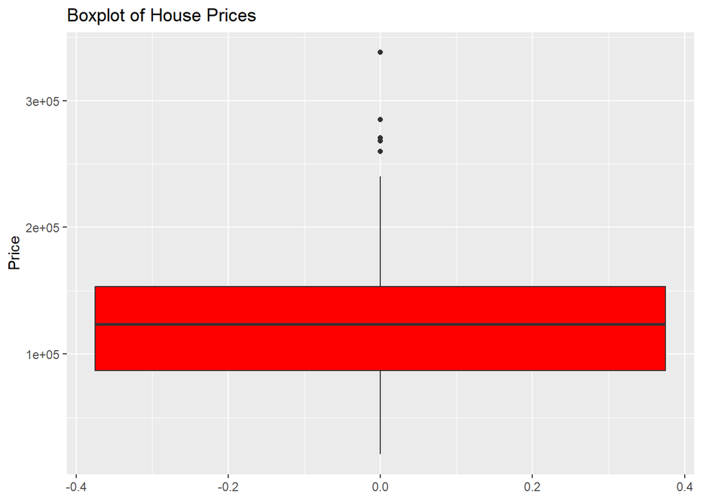

```r
#Solution for question d:
# Boxplot for prices
ggplot(housing_data, aes(y = price)) +
  geom_boxplot(fill = "red") +
  ggtitle("Boxplot of House Prices") +
  ylab("Price")
```

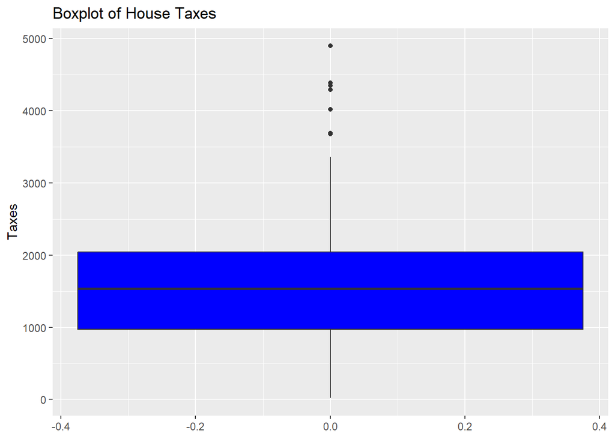

```r
# Boxplot for taxes
ggplot(housing_data, aes(y = Taxes)) +
  geom_boxplot(fill = "blue") +
  ggtitle("Boxplot of House Taxes") +
  ylab("Taxes")
```